# TidyModels: modeltime + cross-validation

UPDATE: 2022-12-24 04:35:24

# はじめに

`tidymodels`パッケージの使い方をいくつかのノートに分けてまとめている。`tidymodels`パッケージは、統計モデルや機械学習モデルを構築するために必要なパッケージをコレクションしているパッケージで、非常に色んなパッケージがある。ここでは、今回は`modeltime`パッケージ + `cross-validation`についてまとめていく。モデルの数理的な側面や機械学習の用語などは、このノートでは扱わない。

下記の公式ドキュメントや`tidymodels`パッケージに関する書籍を参考にしている。

- [Tidymodels](https://www.tidymodels.org/)
- [Tidy Modeling with R](https://www.tmwr.org/software-modeling.html)

## `modeltime`パッケージの目的

`modeltime`パッケージは、時系列モデルの構築を効率よく行うためのパッケージで、`tidymodels`パッケージと組み合わせて時系列モデルを作成する際に使用される。時系列予測のための体系的なワークフローを提供し、時系列ブーストモデルなど新しいアルゴリズムもカバーしている点が特徴的。

前回は基本的な使い方をまとめており、時系列モデルのクロスバリデーションを扱う。

- [Getting Started with Modeltime Resample](https://cran.r-project.org/web/packages/modeltime.resample/vignettes/getting-started.html)

上記のサイトをなぞりながら、不明点を追記しながらまとめていく。

## モデルの作成

まずは必要なパッケージを読み込んでおく。

```r
library(tidymodels)
library(modeltime)
library(tidyverse)
library(lubridate)
library(timetk)

# クロスバリデーションには下記のパッケージが追加で必要
library(modeltime.resample)
```

前回同様、ここでも`timetk`パッケージ内の`m4_monthly`データセットの`id`が`M750`の部分を使用する。データは、1990-01-01から始まり、2015-06-01まである。レコード数は306レコードで、間隔は月単位のデータになっている。

```r
m750 <- m4_monthly %>% filter(id == "M750")
m750 %>%
  summarise(start_date = min(date), end_date = max(date), records = n())
```

```
## # A tibble: 1 × 3
##   start_date end_date   records
##   <date>     <date>       <int>
## 1 1990-01-01 2015-06-01     306
```

このようなデータをここでは扱う。

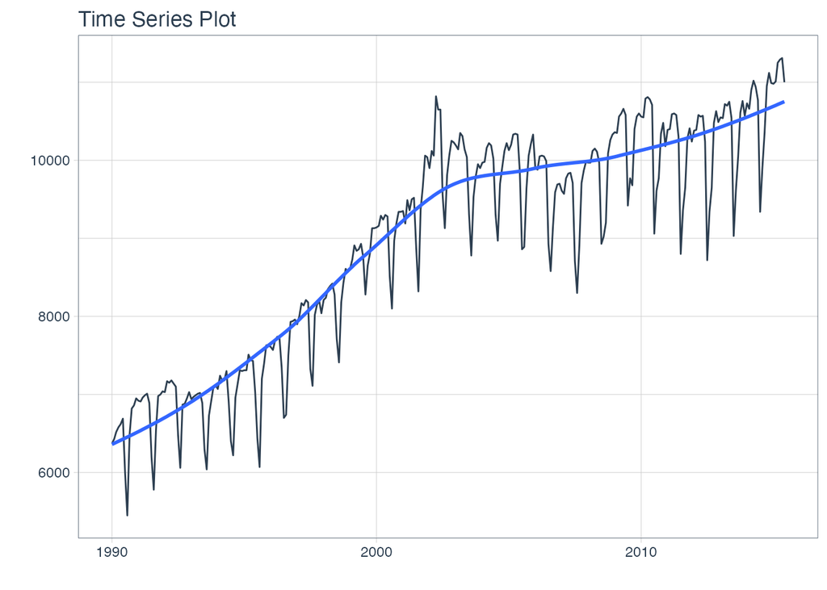

```r
m750 %>%
  plot_time_series(.data = ., .date_var = date, .value = value, .interactive = FALSE)
```

```r
resamples_tscv <- time_series_cv(
    data        = m750,
    assess      = "2 years",
    initial     = "5 years",
    skip        = "1 years",
    slice_limit = 3
)

resamples_tscv %>%
  mutate(
    analysis = map(.x = splits, .f = function(x){analysis(x)}),
    assessment = map(.x = splits, .f = function(x){assessment(x)}),
    analysis_min_date = map(.x = analysis, .f = function(x){min(x$date)}),
    analysis_max_date = map(.x = analysis, .f = function(x){max(x$date)}),
    assessment_min_date = map(.x = assessment, .f = function(x){min(x$date)}),
    assessment_max_date = map(.x = assessment, .f = function(x){max(x$date)}),
  ) %>%
  unnest(analysis_min_date,
         analysis_max_date,
         assessment_min_date,
         assessment_max_date
         )
```

```
## # A tibble: 3 × 8
##   splits          id     analysis assessment analysis_mi…¹ analysis…² assessme…³
##   <list>          <chr>  <list>   <list>     <date>        <date>     <date>
## 1 <split [60/24]> Slice1 <tibble> <tibble>   2008-07-01    2013-06-01 2013-07-01
## 2 <split [60/24]> Slice2 <tibble> <tibble>   2007-07-01    2012-06-01 2012-07-01
## 3 <split [60/24]> Slice3 <tibble> <tibble>   2006-07-01    2011-06-01 2011-07-01
## # … with 1 more variable: assessment_max_date <date>, and abbreviated variable
## #   names ¹analysis_min_date, ²analysis_max_date, ³assessment_min_date
```

そのまま`plot_time_series_cv_plan`関数に渡すことで、クロスバリデーションの状態を可視化できる。

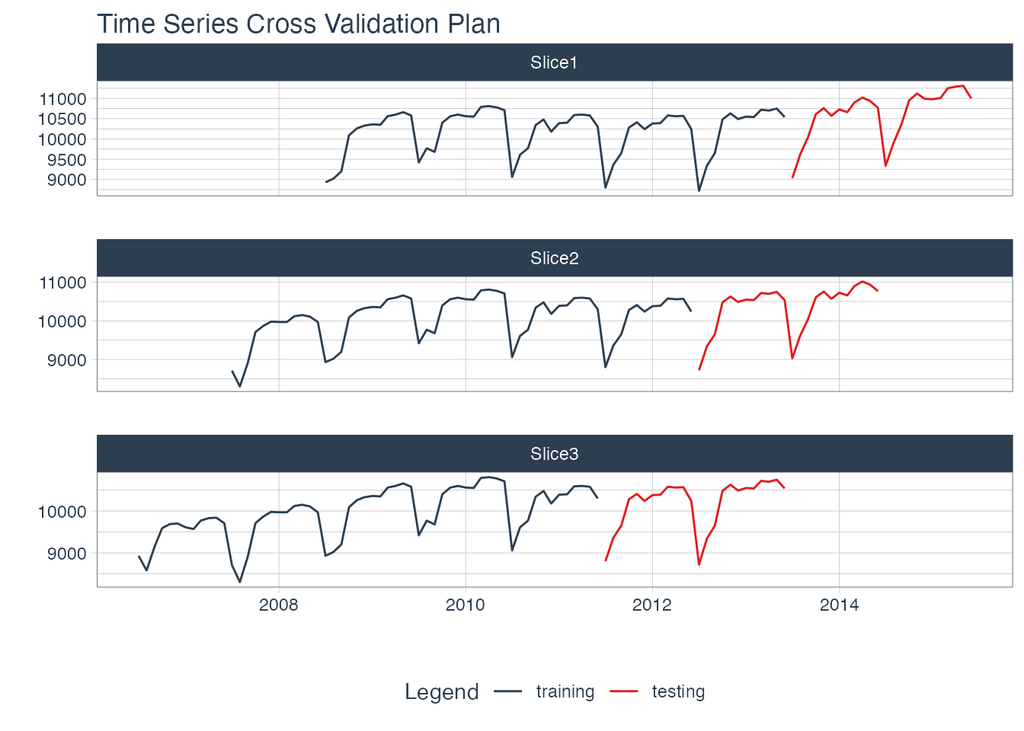

```r
resamples_tscv %>%
  tk_time_series_cv_plan() %>%
  plot_time_series_cv_plan(date, value, .interactive = FALSE)
```

データの準備が整ったので、モデルを設定する。前回同様のモデルを利用するので、実行結果を乗せておく。

```r
# Model1 ARIMA
model_fit_arima <- arima_reg() %>%
    set_engine(engine = "auto_arima") %>%
    fit(value ~ date, data = m750)

# Model2 Prophet
model_fit_prophet <- prophet_reg(seasonality_yearly = TRUE) %>%
    set_engine(engine = "prophet") %>%
    fit(value ~ date, data = m750)

# Recipe For RandomForest & Prophet Boost
recipe <- recipe(value ~ date, m750) %>%
  step_timeseries_signature(date) %>%
  step_rm(
    contains("am.pm"),
    contains("hour"),
    contains("minute"),
    contains("second"),
    contains("xts")
  ) %>%
  step_fourier(date, period = 365, K = 5) %>%
  step_dummy(all_nominal())

# Model Spec For RandomForest
model_randomforest <- rand_forest(trees = 1000, min_n = 50, mtry = 15) %>%
  set_engine("ranger") %>%
  set_mode("regression")

# Model Fitting For RandomForest
model_fit_randomforest <- workflow() %>%
  add_model(model_randomforest) %>%
  add_recipe(recipe %>% step_rm(date)) %>%
  fit(m750)

# Model Spec For Prophet Boost
model_prophet_boost <- prophet_boost(seasonality_yearly = TRUE) %>%
  set_engine("prophet_xgboost")

# Model Fitting For Prophet Boost
model_fit_prophet_boost <- workflow() %>%
  add_model(model_prophet_boost) %>%
  add_recipe(recipe) %>%
  fit(m750)
```

モデルのフィッティングが完了したらモデルテーブルに追加する(`modeltime_table`関数)。これは、クロスバリデーションするのに、訓練データでフィッティングする理由は、モデルテーブルには、フィッティングしてあるモデルしか登録できないため(`All objects must be fitted workflow or parsnip models`)。この後にクロスバリデーションを行なうことになるので形式的な作業である。

```r
models_tbl <- modeltime_table(
    model_fit_arima,
    model_fit_prophet,
    model_fit_prophet_boost,
    model_fit_randomforest
)
models_tbl
```

```
## # Modeltime Table
## # A tibble: 4 × 3
##   .model_id .model     .model_desc
##       <int> <list>     <chr>
## 1         1 <fit[+]>   ARIMA(0,1,1)(0,1,1)[12]
## 2         2 <fit[+]>   PROPHET
## 3         3 <workflow> PROPHET W/ XGBOOST ERRORS
## 4         4 <workflow> RANGER
```

リサンプル予測の生成は`modeltime_fit_resamples`関数で行なう。この時、内部的には、各モデルはリサンプルの各トレーニングセットで再学習される。モデルテーブルにリサンプル予測(`.resample_results`)の列が追加される。

```r
resamples_fitted <- models_tbl %>%
    modeltime_fit_resamples(
        resamples = resamples_tscv,
        control   = control_resamples(verbose = FALSE)
    )

resamples_fitted
```

```
## # Modeltime Table
## # A tibble: 4 × 4
##   .model_id .model     .model_desc               .resample_results
##       <int> <list>     <chr>                     <list>
## 1         1 <fit[+]>   ARIMA(0,1,1)(0,1,1)[12]   <rsmp[+]>
## 2         2 <fit[+]>   PROPHET                   <rsmp[+]>
## 3         3 <workflow> PROPHET W/ XGBOOST ERRORS <rsmp[+]>
## 4         4 <workflow> RANGER                    <rsmp[+]>
```

返されるデータフレームは入れ子の入れ子構造になっている。`.resample_results`の中を除くと、データフレームが返されるものの、予測値はまだ見えないので、もう1階層潜る必要がある。

```r
resamples_fitted %>%
  # ARIMA
  pluck(".resample_results", 1)
```

```
## # Resampling results
## # NA
## # A tibble: 3 × 5
##   splits          id     .metrics         .notes           .predictions
##   <list>          <chr>  <list>           <list>           <list>
## 1 <split [60/24]> Slice1 <tibble [1 × 4]> <tibble [0 × 3]> <tibble [24 × 4]>
## 2 <split [60/24]> Slice2 <tibble [1 × 4]> <tibble [0 × 3]> <tibble [24 × 4]>
## 3 <split [60/24]> Slice3 <tibble [1 × 4]> <tibble [0 × 3]> <tibble [24 × 4]>
```

ということで、もう1階層潜って予測値を確認する。`.metrics`には評価指標が記録されている。

```r
resamples_fitted %>%
  # ARIMA
  pluck(".resample_results", 1) %>%
  # 1つ目のフォールドの予測値
  pluck(".predictions", 1)
```

```
## # A tibble: 24 × 4
##     .pred  .row value .config
##     <dbl> <int> <dbl> <chr>
##  1  8977.   283  9030 Preprocessor1_Model1
##  2  9597.   284  9620 Preprocessor1_Model1
##  3  9907.   285 10050 Preprocessor1_Model1
##  4 10737.   286 10610 Preprocessor1_Model1
##  5 10887.   287 10760 Preprocessor1_Model1
##  6 10747.   288 10570 Preprocessor1_Model1
##  7 10807.   289 10730 Preprocessor1_Model1
##  8 10797.   290 10660 Preprocessor1_Model1
##  9 10977.   291 10900 Preprocessor1_Model1
## 10 10957.   292 11020 Preprocessor1_Model1
## # … with 14 more rows
```

`plot_modeltime_resamples`関数を使用することで、モデルのクロスバリデーションの精度を可視化して確認できる。評価指標ごとにファセットが区切られており、Y軸に各クロスバリデーションのフォールド、横軸が指標の精度である。

例えば、モデル4のランダムフォレストは薄い金色の点を見ればよく、どの指標でも精度がよろしくない。

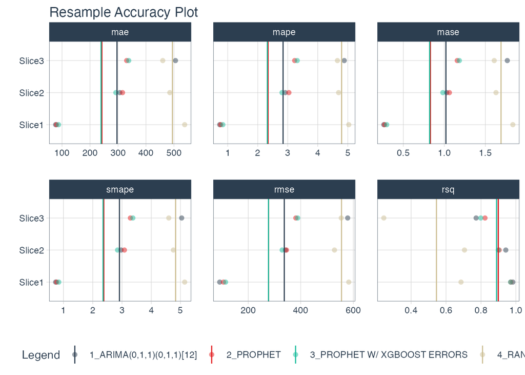

```r
resamples_fitted %>%
    plot_modeltime_resamples(
      .point_size  = 2,
      .point_alpha = 0.5,
      .interactive = FALSE
    )
```

グラフではなく、数表が欲しい場合は、`modeltime_resample_accuracy`関数を利用する。これを見る限り、Prophet Boostが良い事がわかる。

```r
resamples_fitted %>%
    modeltime_resample_accuracy(summary_fns = mean) %>%
    table_modeltime_accuracy(.interactive = FALSE)
```

Accuracy Table

| .model_id | .model_desc | .type | n | mae | mape | mase | smape | rmse | rsq |
| --- | --- | --- | --- | --- | --- | --- | --- | --- | --- |
| 1 | ARIMA(0,1,1)(0,1,1)[12] | Resamples | 3 | 296.32 | 2.84 | 1.02 | 2.91 | 337.44 | 0.90 |
| 2 | PROPHET | Resamples | 3 | 242.46 | 2.34 | 0.83 | 2.38 | 277.74 | 0.90 |
| 3 | PROPHET W/ XGBOOST ERRORS | Resamples | 3 | 239.41 | 2.32 | 0.82 | 2.35 | 277.30 | 0.89 |
| 4 | RANGER | Resamples | 3 | 494.54 | 4.79 | 1.69 | 4.83 | 555.23 | 0.55 |

この結果から、`modeltime_refit`関数を使って、Prophet Boostモデルで、フルデータセットを再学習させて、将来の予測を行なう。ここでは1年先を予測する。

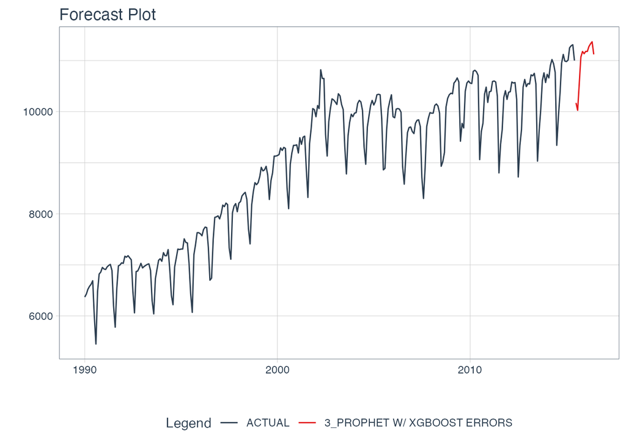

```r
refit_tbl <- resamples_fitted %>%
    filter(.model_id == 3) %>%
    modeltime_refit(data = m750)

refit_tbl %>%
    modeltime_forecast(h = "1 years", actual_data = m750) %>%
    plot_modeltime_forecast(.interactive = FALSE)
```

## 参考文献

- [Tidymodels](https://www.tidymodels.org/)
- [Tidy Modeling with R](https://www.tmwr.org/software-modeling.html)